# Machine Learning - Homework 2

Tamas Koncz

2018-02-04

```r
library(data.table)
library(ggplot2)
library(gridExtra)
library(caret)
library(rpart)
library(skimr)
library(ROCR)
library(zoo)
options(scipen = 999)
theme_set(theme_bw())   # globally set ggplot theme
set.seed(1234)
RMSE <- function(x, true_x) sqrt(mean((x - true_x)^2))
```

#### 1. Predicting mental health problems in the tech sector (8 points)

```r
data <- fread("survey_cleaned.csv")
# data <- fread("../../data/mental-health-in-tech/survey_cleaned.csv")
data <- data[ ,c("comments", "state","work_interfere") := NULL]
data[, age := as.numeric(age)]
data[ , treatment := factor(treatment, levels = c("Yes", "No"))]
```

##### a. Explore some predictors that can be used to predict treatment.

Observing the column descriptions in Kaggle, I decided to use only a subset of the variables for prediction - the reason for this was that with many columns, without further context, it was not possible to decide if they would actually be impacted by the target variable (e.g. I assume that people who have been involved with a medical condition, are much more aware of the related firm policies, etc.)

```r
data[, is_treated := ifelse(treatment == "Yes", 1, 0)]
```

Rather than writing long summaries about what we could observe in the data, let the below plots show the important high-level mechanics:

```r
# gender
dt <- data[ ,.(avg = sum(is_treated) / .N), keyby = gender]
p1 <- ggplot(data = dt) +
  geom_bar(aes(x = gender, y = avg), stat = "identity") +
  scale_y_continuous(limits = c(0, 1), breaks = seq(0, 1, .1)) +
  ylab("Treated % (compared to total)") +
  coord_flip()
```

```r
# country
data[, country_cnt := .N, by = country]
data[, country := ifelse(country_cnt >= 20, country, "Other")]
dt2 <- data[ ,.(avg = sum(is_treated) / .N), keyby = country]
dt2 <- dt2[, country := factor(country, levels = dt2[order(-avg)][["country"]])]
p2 <- ggplot(data = dt2) +
  geom_bar(aes(x = country, y = avg), stat = "identity") +
  scale_y_continuous(limits = c(0, 1), breaks = seq(0, 1, .1)) +
  ylab("Treated % (compared to total)") +
  coord_flip()
```

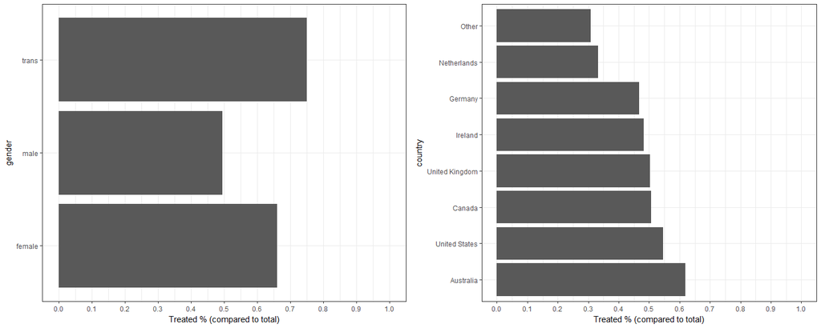

```r
grid.arrange(p1, p2, ncol = 2)
```

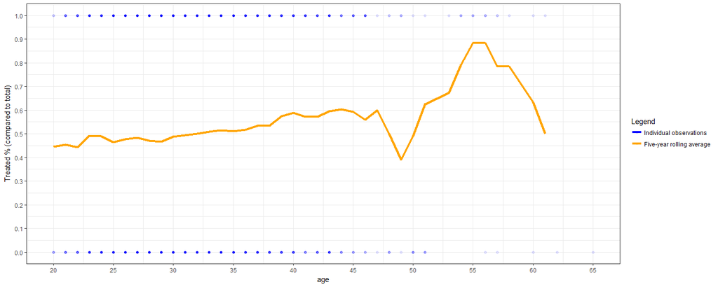

```r
# age
data[, age := round(age)]
data <- data[age >= 18]
data <- data[age <= 65]
dt3 <- data[ ,.(avg = sum(is_treated) / .N), keyby = age]
dt3 <- dt3[order(age)][, rollavg := rollmean(avg, 5, fill = NA)]
ggplot() +
  geom_point(data = data, aes(x = age, y = is_treated, color = "blue"), stat = "identity", alpha = .1)  +
  geom_line(data = dt3, aes(x = age, y = rollavg, color = "orange"), size = 1.5) +
  scale_y_continuous(limits = c(0, 1), breaks = seq(0, 1, .1)) +
  scale_x_continuous(limits = c(20, 65), breaks = seq(20, 65, 5)) +
  ylab("Treated % (compared to total)") +
  scale_colour_manual(name = 'Legend',
                      values = c('blue'='blue','orange'='orange'),
                      labels = c('Individual observations','Five-year rolling average'))
```

```r
# family_history
dt4 <- data[ ,.(avg = sum(is_treated) / .N), keyby = family_history]
p4 <- ggplot(data = dt4) +
  geom_bar(aes(x = family_history, y = avg), stat = "identity") +
  scale_y_continuous(limits = c(0, 1), breaks = seq(0, 1, .1)) +
  ylab("Treated % (compared to total)") +
  coord_flip()
```

```r
# self_employed -- > not much differentiating & lot of missing values (those could be likely extrapolated)
dt5 <- data[ ,.(avg = sum(is_treated) / .N), keyby = remote_work]
p5 <- ggplot(data = dt5) +
  geom_bar(aes(x = remote_work, y = avg), stat = "identity") +
  scale_y_continuous(limits = c(0, 1), breaks = seq(0, 1, .1)) +
  ylab("Treated % (compared to total)") +
  coord_flip()
```

```r
data[, no_employees := factor(no_employees, levels = c("1-5", "6-25", "26-100", "100-500", "500-1000", "More than 1000"))]
dt6 <- data[ ,.(avg = sum(is_treated) / .N), keyby = no_employees]
p6 <- ggplot(data = dt6) +
  geom_bar(aes(x = no_employees, y = avg), stat = "identity") +
  scale_y_continuous(limits = c(0, 1), breaks = seq(0, 1, .1)) +
  ylab("Treated % (compared to total)") +
  coord_flip()
```

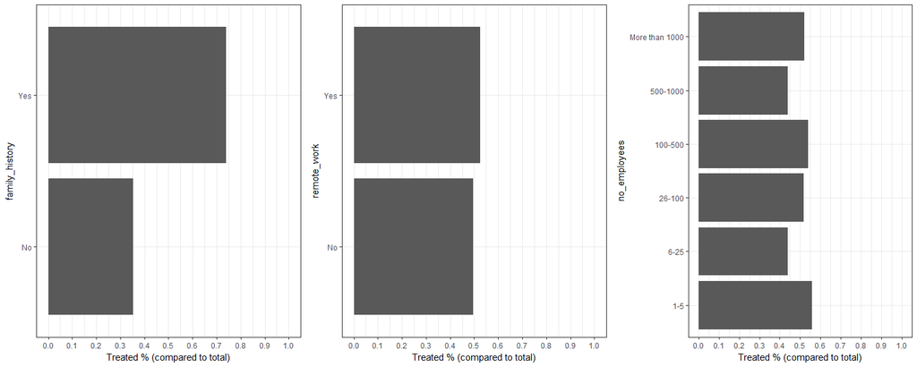

```r
grid.arrange(p4, p5, p6, ncol = 3)
```

Keep only the observations that we’ll use for prediction:

```r
data <- data[, c("treatment", "no_employees", "self_employed",
                  "remote_work", "family_history", "age", "country",
                  "gender")]
```

##### b. Partition your data to 70% training and 30% test samples.

```r
training_ratio <- 0.7
set.seed(1234)
train_indices <- createDataPartition(y = data[["treatment"]],
                                     times = 1,
                                     p = training_ratio,
                                     list = FALSE)
data_train <- data[train_indices, ]
data_test <- data[-train_indices, ]
```

##### c. Build models with glmnet and rpart that predict the binary outcome of treatment (you don’t have to use all variables if you don’t want to - experiment! Just use the same variables for both model families). Use cross-validation on the training set and use AUC as a selection measure (use metric = “ROC” in train and also don’t forget to use classProbs = TRUE, summaryFunction = twoClassSummary in trainControl). Make sure to set the same seed before each call to train.

```r
fit_control <- trainControl(method = "cv", number = 10, classProbs = TRUE, summaryFunction = twoClassSummary)
# rpart
set.seed(1234)
rpart_fit <- train(treatment ~ .,
                   data = data_train,
                   method = "rpart",
                   metric = "ROC",
                   trControl = fit_control)
# glmnet
set.seed(1234)
glmnet_fit <- train(treatment ~ .,
                   data = data_train,
                   method = "glmnet",
                   metric = "ROC",
                   trControl = fit_control)
```

##### d. Compare models based on their predictive performance based on the cross-validation information (you can just use the mean AUC to select the best model).

```r
rpart_fit
```

```
CART

875 samples
  7 predictor
  2 classes: 'Yes', 'No'

No pre-processing
Resampling: Cross-Validated (10 fold)
Summary of sample sizes: 788, 788, 788, 787, 788, 787, ...
Resampling results across tuning parameters:

  cp           ROC        Sens       Spec
  0.004608295  0.6728937  0.6346970  0.6795455
  0.009216590  0.6755007  0.6098990  0.7236258
  0.350230415  0.5742336  0.7727273  0.3757400

ROC was used to select the optimal model using the largest value.
The final value used for the model was cp = 0.00921659.
```

```r
glmnet_fit
```

```
glmnet

875 samples
  7 predictor
  2 classes: 'Yes', 'No'

No pre-processing
Resampling: Cross-Validated (10 fold)
Summary of sample sizes: 788, 788, 788, 787, 788, 787, ...
Resampling results across tuning parameters:

  alpha  lambda        ROC        Sens       Spec
  0.10   0.0003631001  0.6895401  0.5962626  0.7418605
  0.10   0.0036310005  0.6906868  0.5894444  0.7534355
  0.10   0.0363100053  0.6922711  0.5894444  0.7603066
  0.55   0.0003631001  0.6895401  0.5962626  0.7418605
  0.55   0.0036310005  0.6934213  0.5894444  0.7580338
  0.55   0.0363100053  0.6871280  0.5848990  0.7718288
  1.00   0.0003631001  0.6899053  0.5962626  0.7441860
  1.00   0.0036310005  0.6930695  0.5894444  0.7603066
  1.00   0.0363100053  0.6660012  0.5848990  0.7718288

ROC was used to select the optimal model using the largest value.
The final values used for the model were alpha = 0.55 and lambda = 0.003631001.
```

The two models have very similar performances when evaluated by AUC on the training set - however, the best glmnet model somewhat outdoes the best tree model (.69 vs .675 AUC), hence I’ll continue with glmnet for evaluation on the test set.

##### e. Evaluate the best model on the test set: draw an ROC curve and calculate and interpret the AUC.

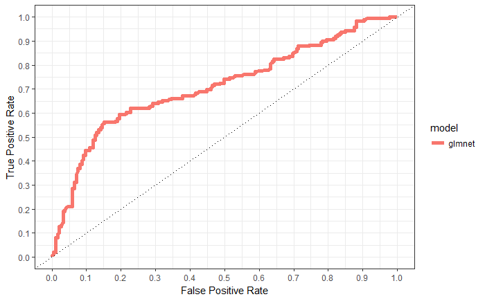

```r
# glmnet
test_prediction_glmnet <- predict.train(glmnet_fit,
                                        newdata = data_test,
                                        type = "prob")
glmnet_prediction <- prediction(test_prediction_glmnet$Yes,
                                data_test[["treatment"]])
glmnet_perf <- performance(glmnet_prediction, measure = "tpr", x.measure = "fpr")
glmnet_roc_df <- data.table(
  model = "glmnet",
  FPR = glmnet_perf@x.values[[1]],
  TPR = glmnet_perf@y.values[[1]],
  cutoff = glmnet_perf@alpha.values[[1]]
)
ggplot(glmnet_roc_df) +
  geom_line(aes(FPR, TPR, color = model), size = 2) +
  geom_abline(intercept = 0, slope = 1,  linetype = "dotted", col = "black") +
  scale_y_continuous(limits = c(0, 1), breaks = seq(0, 1, .1)) +
  scale_x_continuous(limits = c(0, 1), breaks = seq(0, 1, .1)) +
  xlab("False Positive Rate") + ylab("True Positive Rate")
```

```r
# calculate AUC
glmnet_AUC <- performance(glmnet_prediction, measure = "auc")@y.values[[1]]
glmnet_AUC
```

```
[1] 0.7117117
```

If we were to take a random positive and a random negative observation, the model is expected to assign a higher probability to the “treated” case in ~71% of the time.

The model does fairly well at picking up true positives - however, AUC in itself does not tell much about performance (higher is better obviosuly, but what is actually good is very domain specific).

##### If you have to choose a probability threshold to predict the outcome, what would you choose? At this threshold, how large are the true positive rate and the false positive rate? How many false positives and false negatives there are in the test sample?

Selecting a good threshold depends on the actual use case. Let’s say that we are after predicting people who should seek medical help in our organisation - missing someone puts them in a wrong spot, but spending too many people to the doctor could be a significant burden. Hence, our preferences are symmetric for false positives and false negatives.

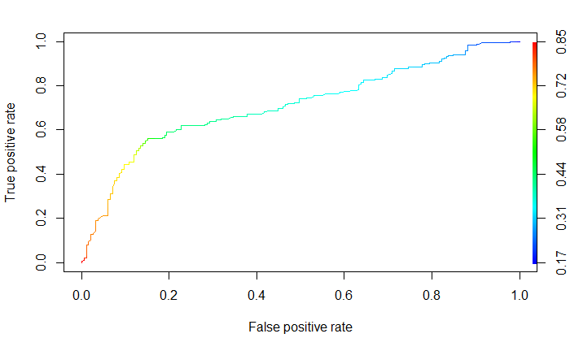

```r
# built-in plot method
plot(performance(glmnet_prediction, "tpr", "fpr"), colorize=TRUE)
```

In this case, I’d choose a cutoff beteen ~0.45 - 0.55 (there is no significant performance difference in this range). The TPR is around 0.6, while the FPR is below 0.2, a well-balanced trade-off for our case.

```r
confusionMatrix(test_prediction, data_test[["treatment"]])
```

```
Confusion Matrix and Statistics

          Reference
Prediction Yes  No
       Yes 104  27
       No   85 158

               Accuracy : 0.7005
                 95% CI : (0.6513, 0.7465)
    No Information Rate : 0.5053
    P-Value [Acc > NIR] : 0.00000000000001403

                  Kappa : 0.403
 Mcnemar's Test P-Value : 0.00000007204547014

            Sensitivity : 0.5503
            Specificity : 0.8541
         Pos Pred Value : 0.7939
         Neg Pred Value : 0.6502
             Prevalence : 0.5053
         Detection Rate : 0.2781
   Detection Prevalence : 0.3503
      Balanced Accuracy : 0.7022

       'Positive' Class : Yes
```

#### 2. Transformed scores (5 points)

```r
data <- fread("no-show-data.csv")
# data <- fread("../../data/medical-appointments-no-show/no-show-data.csv")
```

```r
# [... apply the cleaning steps we did in class ...]
data[, c("PatientId", "AppointmentID", "Neighbourhood") := NULL]
setnames(data,
         c("No-show",
           "Age",
           "Gender",
           "ScheduledDay",
           "AppointmentDay",
           "Scholarship",
           "Hipertension",
           "Diabetes",
           "Alcoholism",
           "Handcap",
           "SMS_received"),
         c("no_show",
           "age",
           "gender",
           "scheduled_day",
           "appointment_day",
           "scholarship",
           "hypertension",
           "diabetes",
           "alcoholism",
           "handicap",
           "sms_received"))
# clean up a little bit
data <- data[age %between% c(0, 95)]
# for binary prediction with caret, the target variable must be a factor
data[, no_show := factor(no_show, levels = c("Yes", "No"))]
data[, no_show_num := ifelse(no_show == "Yes", 1, 0)]
data[, handicap := ifelse(handicap > 0, 1, 0)]
# create new variables
data[, scheduled_day := as.Date(scheduled_day)]
data[, appointment_day := as.Date(appointment_day)]
data[, days_since_scheduled := as.integer(appointment_day - scheduled_day)]
data <- data
data[, no_show_num := NULL]
data[, days_category := cut(
  days_since_scheduled,
  breaks = c(-1, 0, 1, 2, 5, 10, 30, Inf),
  include.lowest = TRUE)]
data[, age_category := cut(age,
                           breaks = seq(0, 100, by = 5),
                           include.lowest = TRUE)]
```

```r
# [... create train and test sets ... ]
training_ratio <- 0.5
set.seed(1234)
train_indices <- createDataPartition(y = data[["no_show"]],
                                     times = 1,
                                     p = training_ratio,
                                     list = FALSE)
data_train <- data[train_indices, ]
data_test <- data[-train_indices, ]
```

```r
train_control <- trainControl(method = "cv",
                              number = 5,
                              classProbs = TRUE,
                              summaryFunction = twoClassSummary)
set.seed(1234)
model <- train(no_show ~ days_category +
                                poly(age, 3) +
                                scholarship +
                                gender +
                                alcoholism +
                                diabetes,
                      data = data_train,
                      method = "glmnet",
                      trControl = train_control,
                      metric = "ROC")
```

|  | Yes | No | Yes | No |
| --- | --- | --- | --- | --- |
| 1 | 0.02953606 | 0.9704639 | 0.1718606 | 0.9851213 |
| 2 | 0.04050826 | 0.9594917 | 0.2012666 | 0.9795365 |
| 3 | 0.15773322 | 0.8422668 | 0.3971564 | 0.9177509 |
| 4 | 0.30064216 | 0.6993578 | 0.5483085 | 0.8362762 |
| 5 | 0.24924990 | 0.7507501 | 0.4992493 | 0.8664584 |
| 6 | 0.28348668 | 0.7165133 | 0.5324347 | 0.8464711 |

#### a. Draw ROC curves for all three scores and calculate the AUC. How do they compare? Is it surprising in light of the interpretation of the AUC?

```r
# simple
simple_prediction <- prediction(prediction$Yes, data_test[["no_show"]])
simple_perf <- performance(simple_prediction, measure = "tpr", x.measure = "fpr")
simple_roc_df <- data.table(
  prediction = "simple",
  FPR = simple_perf@x.values[[1]],
  TPR = simple_perf@y.values[[1]],
  cutoff = simple_perf@alpha.values[[1]]
)
# sqrt
sqrt_prediction <- prediction(prediction_sqrt$Yes, data_test[["no_show"]])
sqrt_perf <- performance(sqrt_prediction, measure = "tpr", x.measure = "fpr")
sqrt_roc_df <- data.table(
  prediction = "sqrt",
  FPR = sqrt_perf@x.values[[1]],
  TPR = sqrt_perf@y.values[[1]],
  cutoff = sqrt_perf@alpha.values[[1]]
)
# sq
sq_prediction <- prediction(prediction_sq$Yes, data_test[["no_show"]])
sq_perf <- performance(sq_prediction, measure = "tpr", x.measure = "fpr")
sq_roc_df <- data.table(
  prediction = "sq",
  FPR = sq_perf@x.values[[1]],
  TPR = sq_perf@y.values[[1]],
  cutoff = sq_perf@alpha.values[[1]]
)
```

```r
roc_df <- rbind(simple_roc_df, sqrt_roc_df)
roc_df <- rbind(roc_df, sq_roc_df)
```

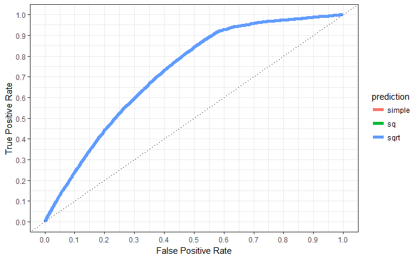

```r
ggplot(roc_df) +
  geom_line(aes(FPR, TPR, color = prediction), size = 2) +
  geom_abline(intercept = 0, slope = 1,  linetype = "dotted", col = "black") +
  scale_y_continuous(limits = c(0, 1), breaks = seq(0, 1, .1)) +
  scale_x_continuous(limits = c(0, 1), breaks = seq(0, 1, .1)) +
  xlab("False Positive Rate") + ylab("True Positive Rate")
```

As it’s visible from the above, the original predictions, and the two after transformations create the same ROC curves (lines fall on each other).

#### b. What is the key, common property of both the square root and the square functions that leads to this finding?

If we do a symmetrical transformation like square functions, that also keeps probabilities in the 0-1 range, the shape of the ROC curve won’t change - as that is driven by the ratio of TPR vs FPR, both of which are impacted by these transformations. However, if we would plot the relevant probabilities as well, they would move around the chart.

#### c. Draw a calibration plot for all three scores separately:

#### 1. group people into bins based on predicted scores

#### 2. display on a scatterplot the mean of the predicted scores versus the actual share of people surviving

```r
test_truth <- data_test[["no_show"]]
truth_numeric <- ifelse(test_truth == "Yes", 1, 0)
```

[figure not shown]

```r
score_sqrt <- prediction_sqrt$Yes
actual_vs_predicted <- data.table(actual = truth_numeric,
                                  predicted = score_sqrt)
actual_vs_predicted[, score_category := cut(predicted,
                                    seq(0, 0.6, 0.05),
                                    include.lowest = TRUE)]
calibration <- actual_vs_predicted[, .(mean_actual = mean(actual),
                                       mean_predicted = mean(predicted),
                                       num_obs = .N),
                                   keyby = .(score_category)]
p2 <- ggplot(calibration,
       aes(x = mean_actual, y = mean_predicted, size = num_obs)) +
  geom_point() +
  geom_abline(intercept = 0, slope = 1, linetype = "dashed") +
  ylim(0, 1) + xlim(0, 1) +
  xlab("Actual frequencies") + ylab("Predicted probabilities") +
  labs(title= "SQRT transformation")
```

```r
score_sq <- prediction_sq$Yes
actual_vs_predicted <- data.table(actual = truth_numeric,
                                  predicted = score_sq)
actual_vs_predicted[, score_category := cut(predicted,
                                    seq(0, 0.6, 0.05),
                                    include.lowest = TRUE)]
calibration <- actual_vs_predicted[, .(mean_actual = mean(actual),
                                       mean_predicted = mean(predicted),
                                       num_obs = .N),
                                   keyby = .(score_category)]
p3 <- ggplot(calibration,
       aes(x = mean_actual, y = mean_predicted, size = num_obs)) +
  geom_point() +
  geom_abline(intercept = 0, slope = 1, linetype = "dashed") +
  ylim(0, 1) + xlim(0, 1) +
  xlab("Actual frequencies") + ylab("Predicted probabilities") +
  labs(title= "SQ transformation")
```

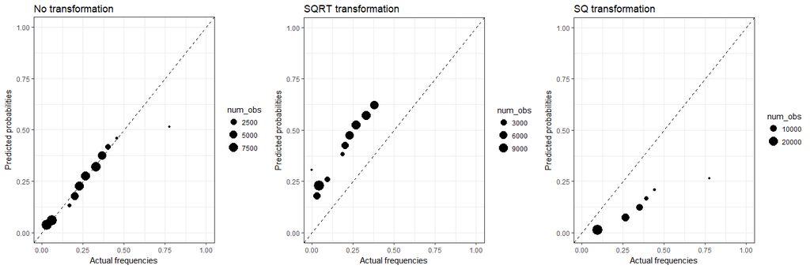

```r
grid.arrange(p1, p2, p3, ncol = 3)
```

#### How do they compare? Which score(s) can be regarded as well-calibrated probabilites?

As we can see, the predictions with no transformation can be seen as well-calibrated (apart from a small group of high-yes-rate observations, which is neglible). The other two are not well-calibrated, however this should be no surprise - we have transformed the predicted probabilities, but the original frequencies did not change, hence they will be out of sync.